# Suicde Prevention in Oregon Public Schools

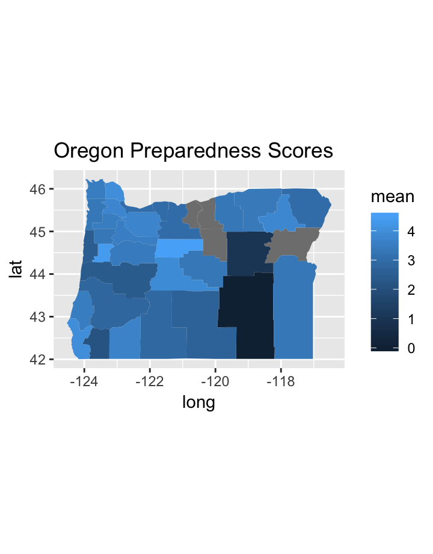

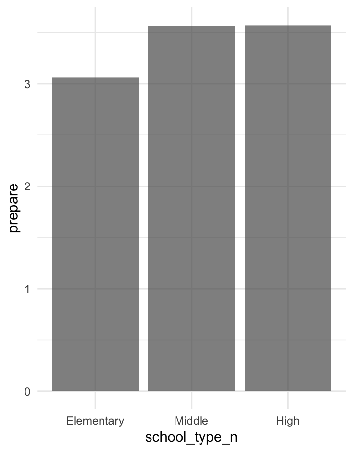

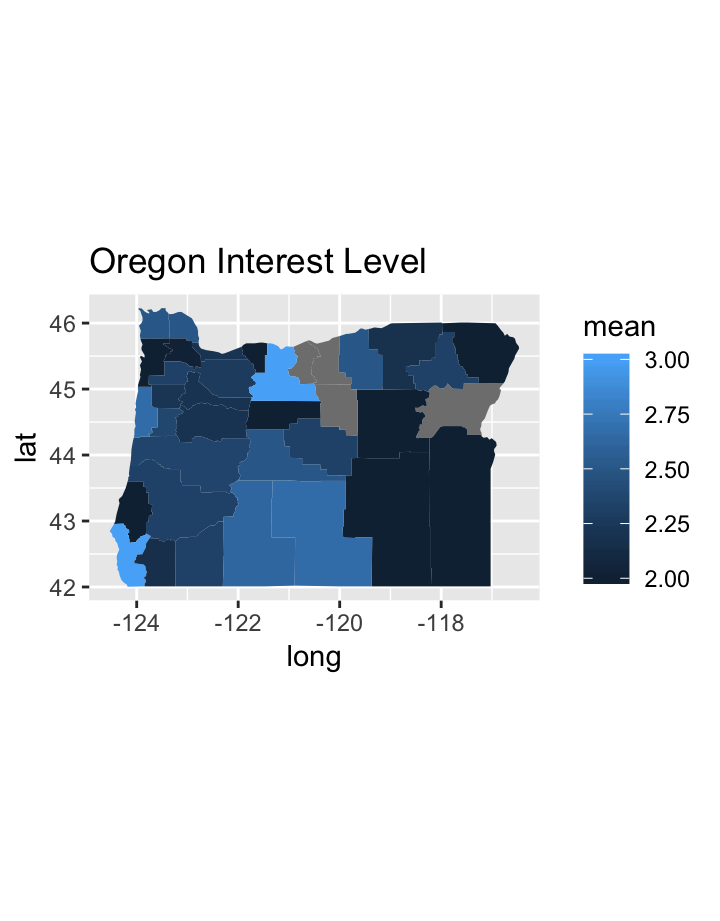

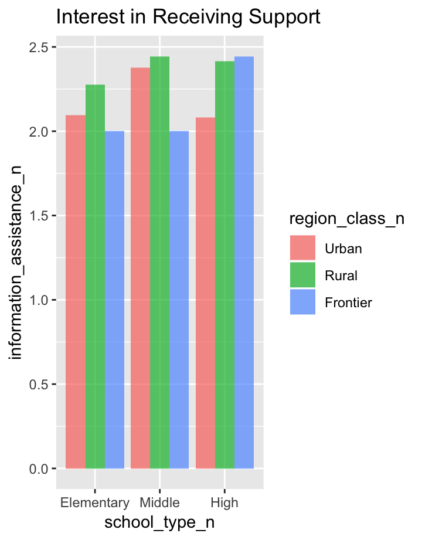

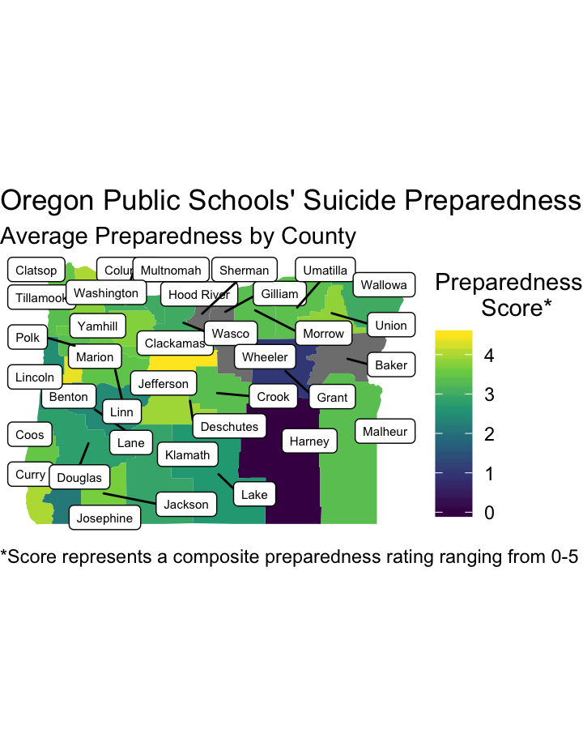

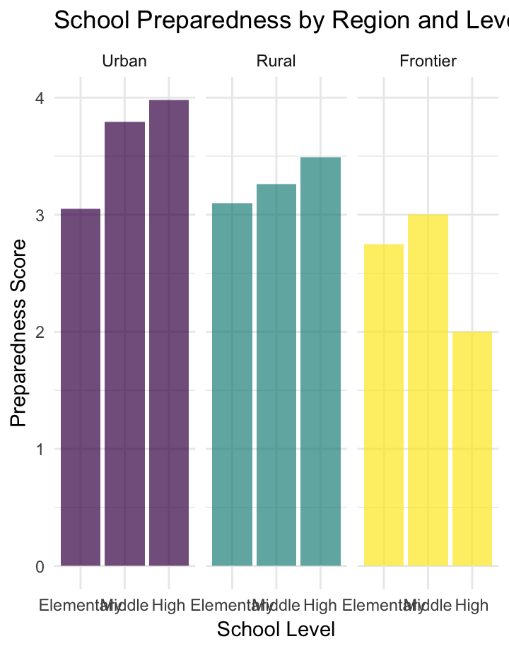

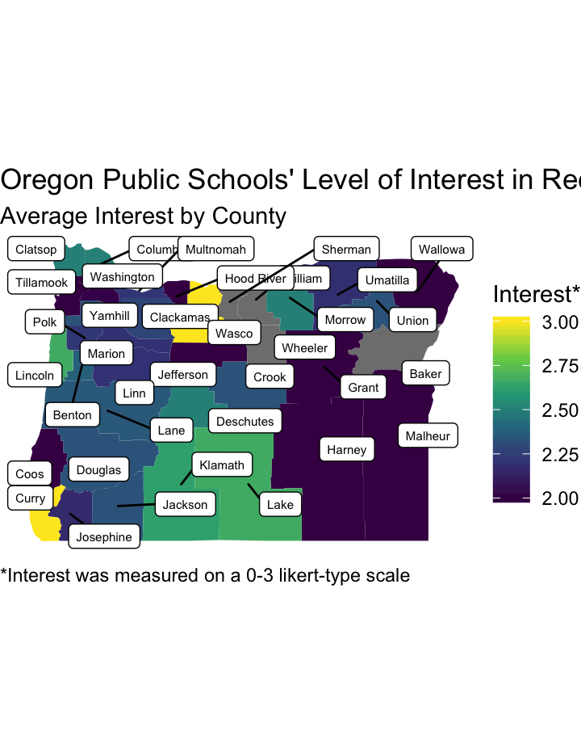

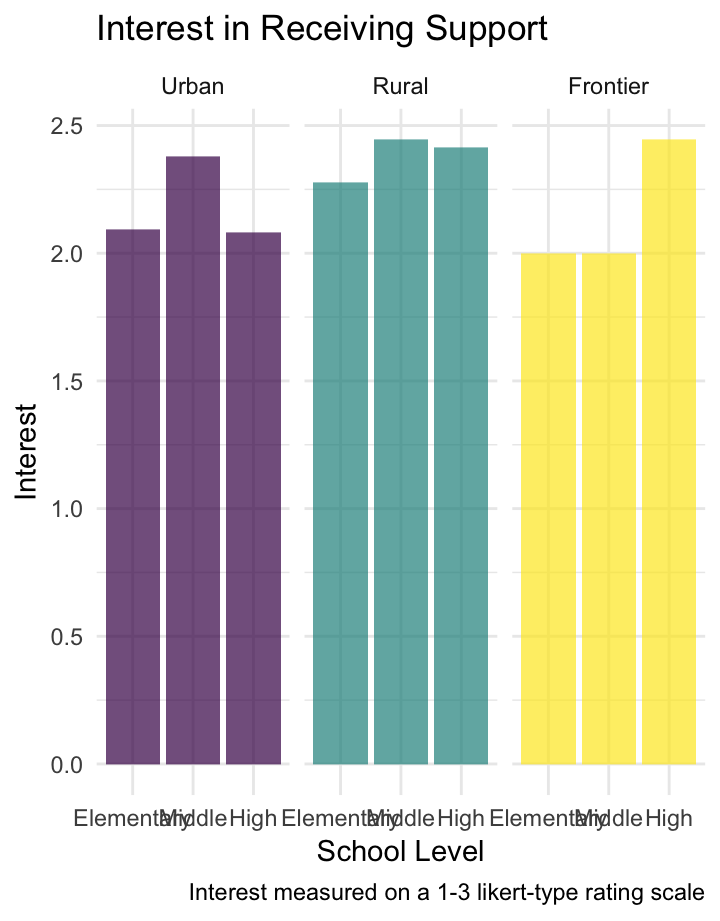

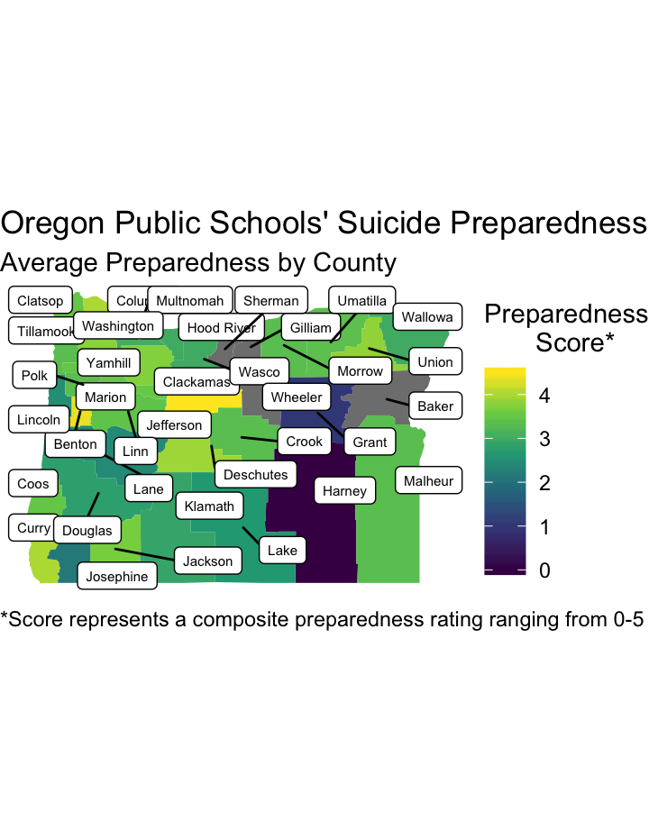

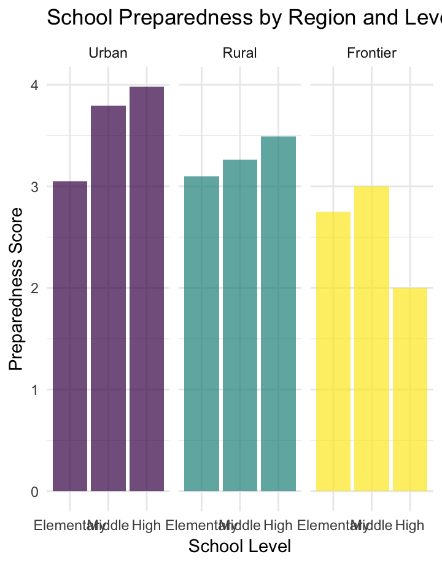

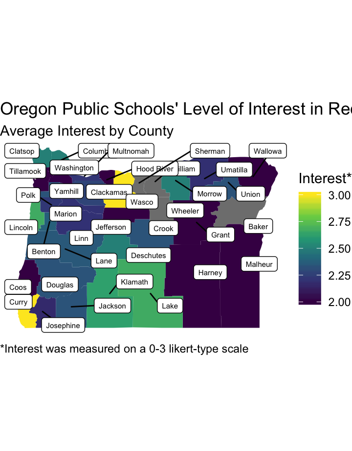

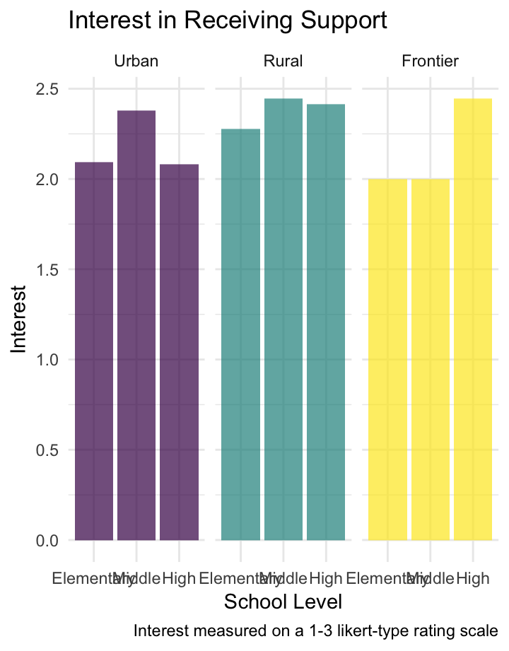

# The Genesis

### State Map

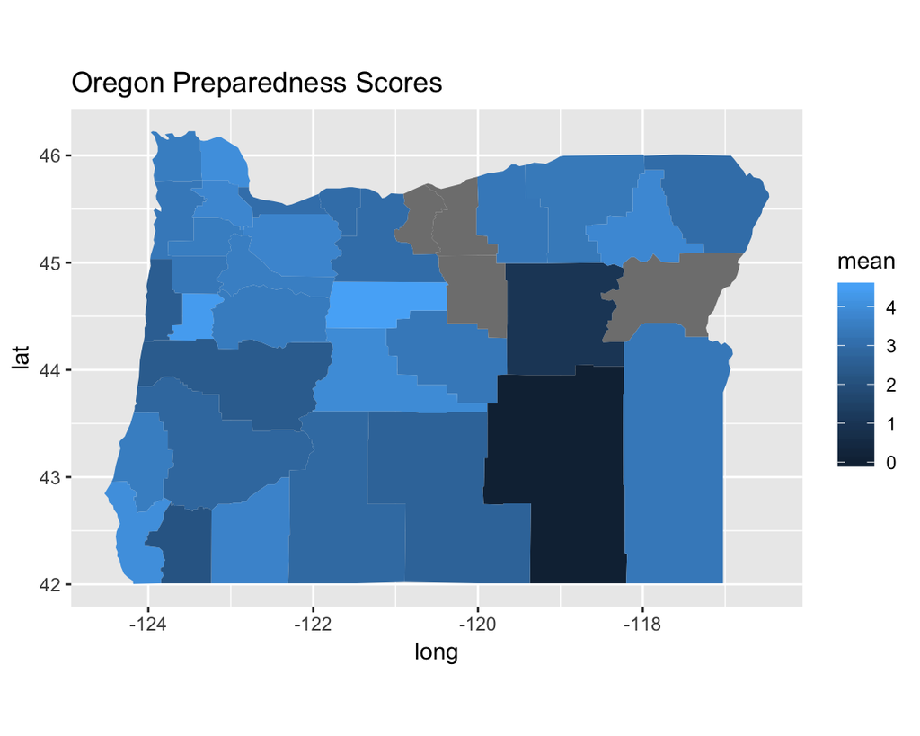

### Bar Graph

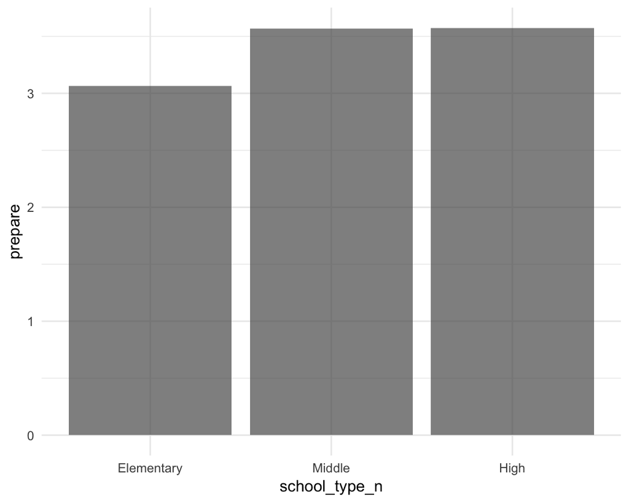

### State Map

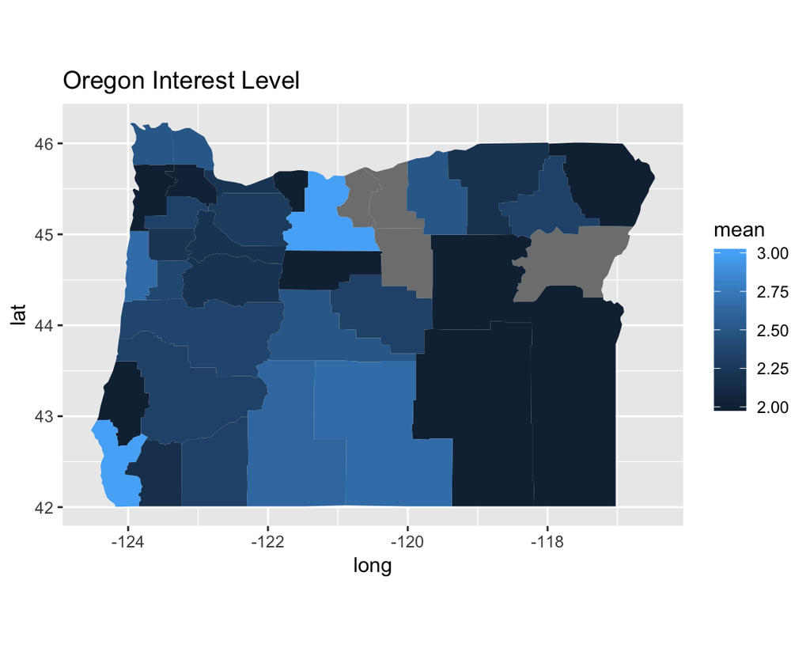

### Bar Graph

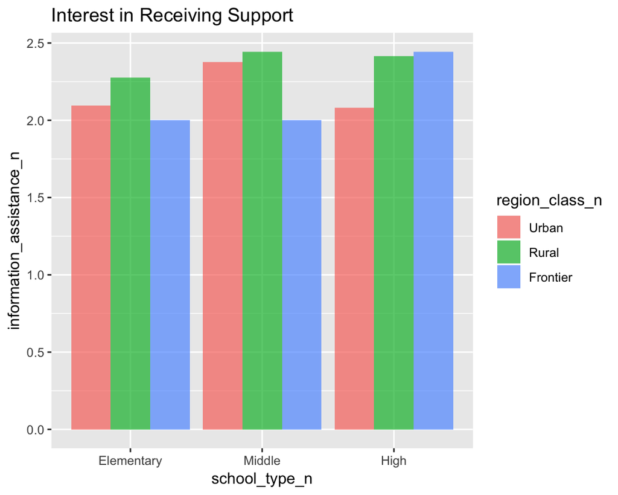

> *The data that I used for this portfolio was collected during a statewide survey of all 1,251 Oregon public schools. The survey gathered information on suicide prevention activities at each school site. Although the response rate was moderate, with 403 schools responding, the data that was collected helps provide a glimpse into the general landscape of suicide prevention in schools across the state.

# The Overview

### State Map

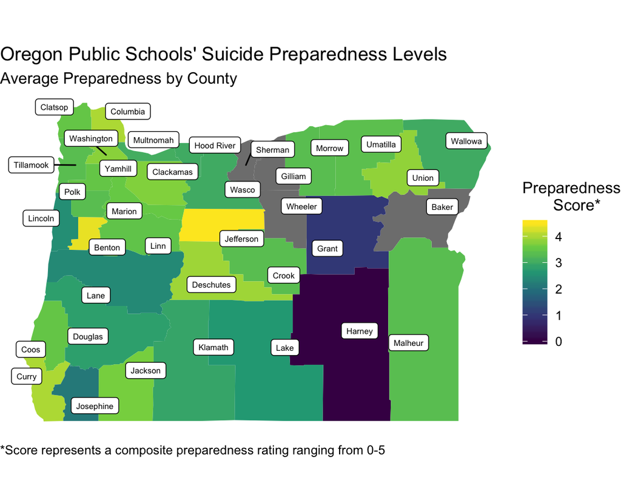

### Bar Graph

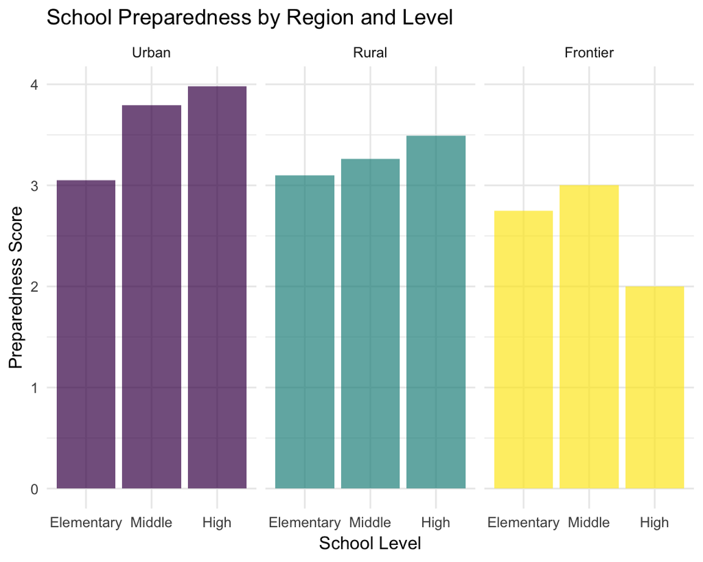

### State Map

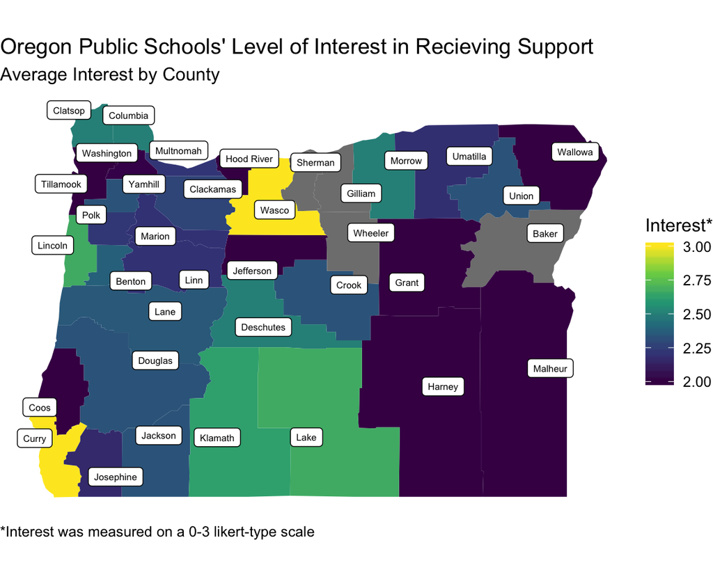

### Bar Graph

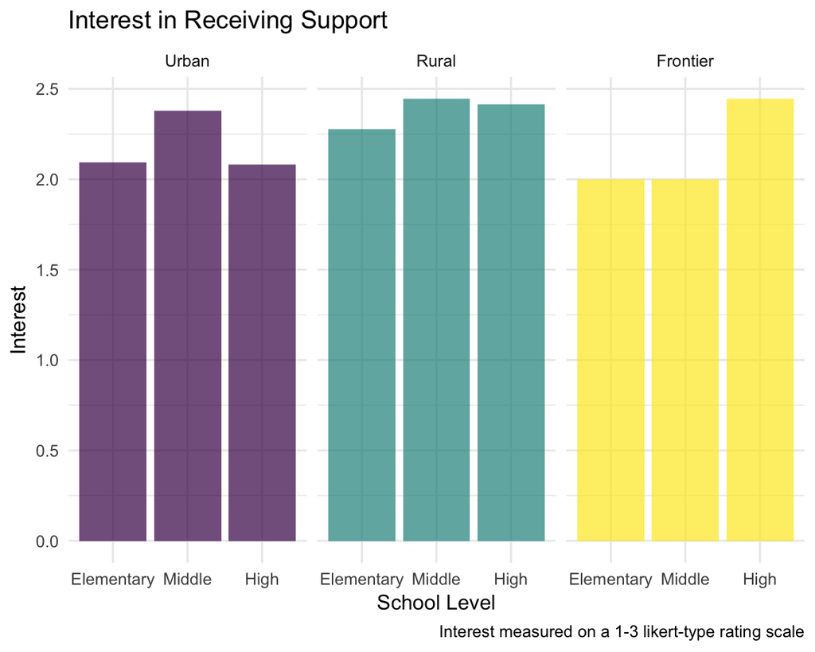

# Preparedness 1

### State Map

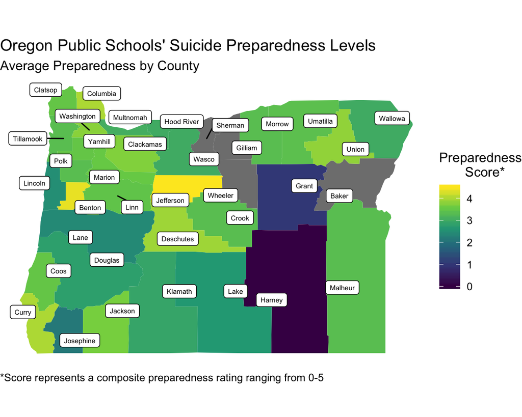

> This is the graph where it all started. I naturally have an affinity for all maps geographical and knew that whatever my portfolio entailed, it would most definitely include a “geom_polygon.” I started by creating a “preparedness composite score” that entailed scoring schools (0 = No, 1 = Yes) on the following five factors: (a) Postvention Plan, (b) EBP, (c) Memorandum of Understanding, (d) Identify and Refer Protocol, and (e) supplementary activities. Once the composite score was created, I to calculated the average for each county and then merged it with the map data. All of that was pretty straightforward. I have actually been surprised how (relatively) easy it has been working with maps, even in spite of them seeming intimidating. Once the data was merged and plotted, I ran into several obstacles. The first was a color scale that helped tell the story. I decided to go with viridis_c because of the Oregon green theme, although I agree with one of my reviewers that magma was clearer. The two other major issues that I battled with were (a) labels for the counties and (b) borders for the counties. For labels, I decided to finally go with label vs text and also incorporate the repel function. Without the use of repel, the county text is much more centered; however, the overlapping was way too messy. I am not completely sold on the labels vs plain text, but in terms of pure readability, it works much better. I am interested in whether you think that I should use county labels at all. They are distracting but practical. I also spent several hours trying to get the borders to come in as grey, but kept getting an error about continuous variables being needed. I had basically just added the same geom_polygon layer but had “fill = NA.” It did not work. This map will be shared with both lay people (our state agency clients and schools) and researchers (at a presentation at SPR). I am wondering whether the audience would change anything major for how a geom_polygon map is presented. Overall, I am happy with it, but will be interested to hear what you think. The more advice the better!

# Preparedness 2

### Bar Graph

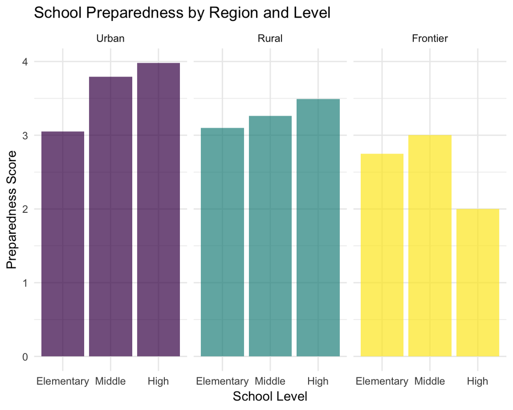

# Interest 1

### State Map

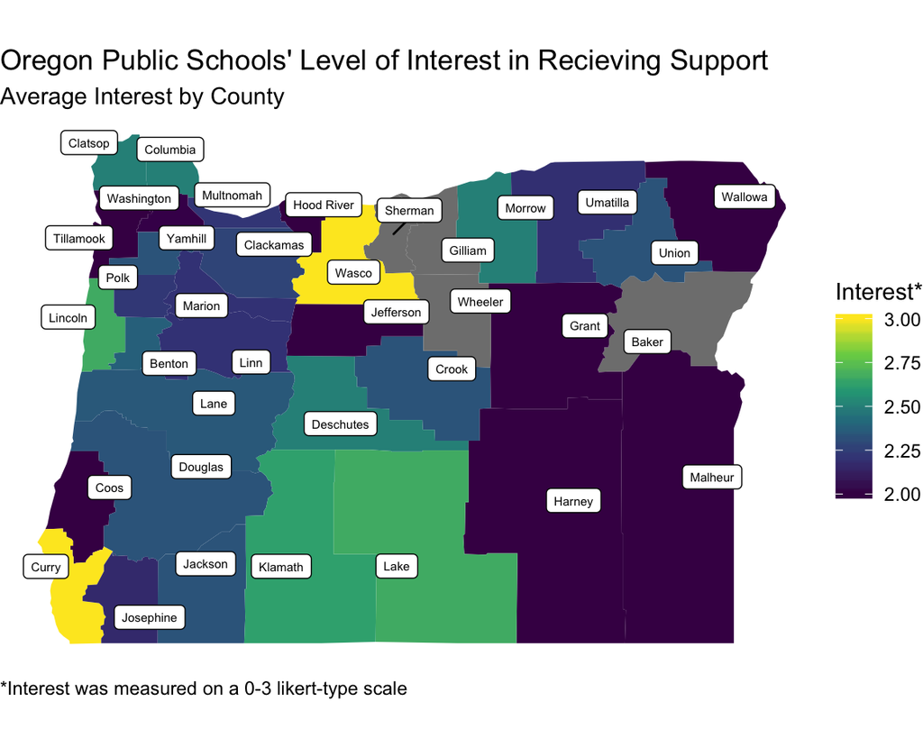

> The second map graph is similar to the first visualization, which I actually think is a strength because it allows the viewer to compare the level of preparedness to the level of interest a school has in receiving support. One challenge that I had with this plot in particular was that originally when I was using geom_text, I could not find a fond that was clearly visible in both the lighter yellow regions and the darker purple regions. Do you have a solution for this? That was one of the major reasons that I went with the label over text choice. Again, I could not get the border to come in, which is a pretty major issue for the huge purple blob of Harney, Grant, and Malheur counties.

# Interest 2

### Bar Graph

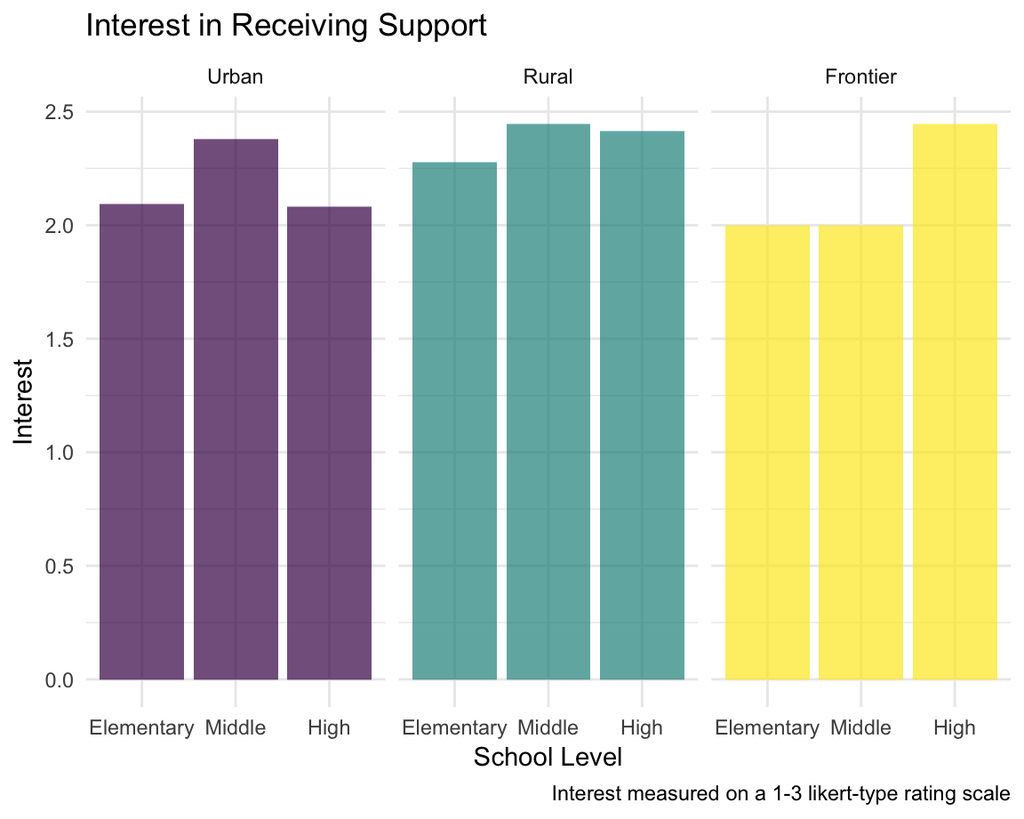